# Customer Targeting with Machine Learning

Philippe Lambot [GitHub](https://github.com/Dev-P-L)

March 1, 2023

| Prospects Selected | Interested Customers Reached (Sensitivity) |
| --- | --- |
| 49% | 80% |

I thank the UCI Machine Learning Repository and the contributors for the [Bank Marketing Data Set](https://archive.ics.uci.edu/ml/datasets/bank+marketing) that has been made available for research. I gratefully cite the contributors: “[Moro et al., 2014] S. Moro, P. Cortez and P. Rita. A Data-Driven Approach to Predict the Success of Bank Telemarketing. Decision Support Systems, Elsevier, 62:22-31, June 2014.”

“The data is related with direct marketing campaigns of a Portuguese banking institution. The marketing campaigns were based on phone calls. Often, more than one contact to the same client was required, in order to access if the product (bank term deposit) would be (‘yes’) or not (‘no’) subscribed.”

From the UCI repository, the version bank.csv has been downloaded.

In this Data Science project, the HTML final report has been uploaded to [my GitHub account](https://github.com/Dev-P-L). Contact information is also available. You are most welcome to get in touch.

## Which Predictors?

The dataset under review is comprised of sixteen predictors. The label indicates whether customers did or did not opt for term deposits in the framework of a direct marketing campaign.

| Predictor | Meaning | Information Type |
| --- | --- | --- |
| Age | Age in years | Customer’s NON-FINANCIAL Profile |
| Job | Professional status | Customer’s NON-FINANCIAL Profile |
| Marital | Marital status | Customer’s NON-FINANCIAL Profile |
| Education | Education | Customer’s NON-FINANCIAL Profile |
| Default | Credit in default? | Customer’s FINANCIAL Profile |
| Balance | Account balance | Customer’s FINANCIAL Profile |
| Housing | Home loan? | Customer’s FINANCIAL Profile |
| Loan | Personal loan? | Customer’s FINANCIAL Profile |
| Contact | Medium of communication with customer in reference campaign | REFERENCE Marketing Campaign |
| Day | Day (of the month) of last contact with customer in reference campaign | REFERENCE Marketing Campaign |
| Month | Month of last contact with customer in reference campaign | REFERENCE Marketing Campaign |
| Duration | Duration in seconds of last contact with customer in reference campaign | REFERENCE Marketing Campaign |
| Campaign | Number of contacts with customer in reference campaign | REFERENCE Marketing Campaign |
| Pdays | Number of days since last contact with customer in previous campaign | PREVIOUS Marketing Campaign |
| Previous | Number of contacts with customer before reference campaign | PREVIOUS Marketing Campaign |
| Poutcome | Outcome from previous marketing campaign with customer | PREVIOUS Marketing Campaign |

## Exploratory Data Analysis (EDA)

Exploratory Data Analysis will be conducted with a view to generating insights about predictive patterns that could facilitate interested customers targeting.

Some terminology from the UCI Machine Learning Repository has been taken over. Indeed, for the sake of simplicity, the word “subscription” has been used to refer to customers opting for bank term deposits.

### Interested Customers Prevalence

The label indicates whether or not a client opted for a term deposit. In the training set, the label produces the following segmentation between customers who opened a term deposit and customers who did not.

| Label | Number of Customers | Percentage |
| --- | --- | --- |
| deposit | 291 | 11.5 |
| no_deposit | 2240 | 88.5 |

The percentage of customers interested in term deposits with respect to all customers of the bank is pretty low — namely 11.5%. Implications for performance metric choice will be commented upon here, when insights from this Exploratory Data Analysis will be listed and summed up.

### Age

Let us visualize the empirical distribution of bank customers according to age in the next histogram before relating that customer distribution by age to average subscription rates by sub-groups formed on the basis of age.

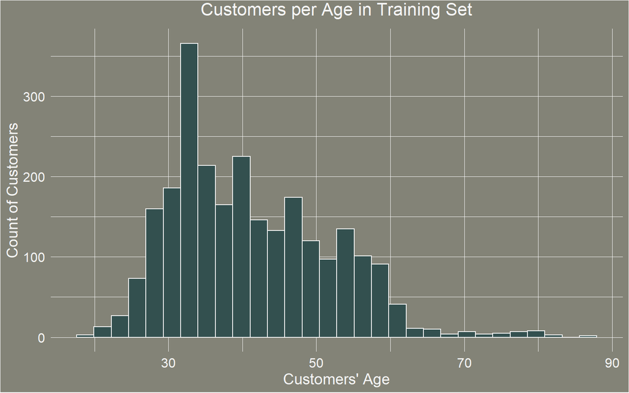

The most populated subgroups are, in descending order, the 30-somethings, the 40-somethings, and the 50-somethings.

Will the same concentration be found in terms of average subscription percentages by age? Let us have a look at a table where average subscription percentages by age are sorted in descending order of percentage.

| Age | Number of Customers | Average Subscription Percentage |
| --- | --- | --- |
| [61,88) | 72 | 39 |
| [19,25) | 43 | 19 |
| [25,30) | 233 | 14 |
| [45,50) | 305 | 12 |
| [50,55) | 239 | 12 |
| [30,35) | 552 | 10 |
| [35,40) | 446 | 10 |
| [40,45) | 367 | 9 |
| [55,61) | 274 | 9 |

The highest subscription percentages are noted below 30 years and above 60.

From a predictive viewpoint, this seems interesting although the impact might be reduced by the rather limited number of customers in the two age categories with the highest average subscription rates.

Anyway, age looks like a possibly impactful predictor.

### Job

The next predictor is job — or rather professional status since there are also retired people, students, and unemployed people. Let us have a look at a barplot by professional status.

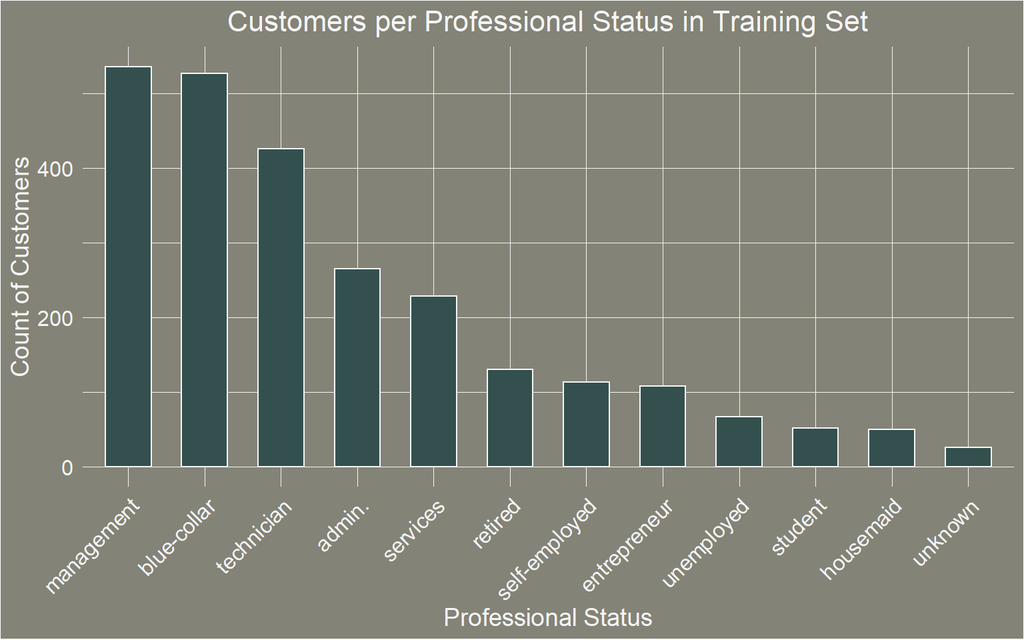

Some subgroups — such as blue-collars and managers — are much more populated than others.

Let us build up a table, which also contains average percentages of interested customers by professional status. Professional statuses are ranked in descending order of subscription percentage.

| Professional Status | Number of Customers | Average Subscription Percentage |
| --- | --- | --- |
| unknown | 26 | 27 |
| retired | 131 | 24 |
| management | 536 | 16 |
| student | 52 | 15 |
| admin. | 265 | 10 |
| self-employed | 114 | 10 |
| technician | 426 | 10 |
| blue-collar | 527 | 9 |
| housemaid | 50 | 8 |
| services | 229 | 8 |
| entrepreneur | 108 | 7 |
| unemployed | 67 | 7 |

The subgroup with “unknown” professional status is first in average subscription percentage with 27%. Retired customers come next, with an average subscription percentage of 24%. Entrepreneurs and unemployed customers have the lowest subscription rate — namely 7%.

Partially, this intersects and corroborates findings about age: customers aged more than 60 have an average subscription rate of 39% — which is the highest in the ranking by age — and retired customers have a percentage of 24% — which is the second one in the ranking by professional status.

But age and professional status are no mere duplicates. For instance, the number of customers over 60 is 72 while the number of retired people is 131.

Professional status could also be an impactful predictor.

### Marital Status

The table below gives the concentration of customers by marital status, distinguishing married people, single, and divorced people — widows and widowers being included in the subgroup referred to as divorced people.

The table also gives the average subscription percentages by marital status.

| Marital Status | Number of Customers | Average Subscription Percentage |
| --- | --- | --- |
| divorced | 278 | 14.7 |
| single | 662 | 14.2 |
| married | 1591 | 9.8 |

The table above shows a clear dichotomy: married customers have an average subscription rate of around 10% while the percentage is somewhat above 14% for both single customers and divorced customers — the subgroup of divorced customers including widows and widowers as well.

Some impactfulness is not excluded.

### Education

The last predictor from the customers’ non-financial status is the education level, distinguishing primary, secondary, tertiary, and unknown levels.

| Education Level | Number of Customers | Average Subscription Percentage |
| --- | --- | --- |
| tertiary | 777 | 15 |
| primary | 354 | 11 |
| secondary | 1305 | 10 |
| unknown | 95 | 9 |

Customers with tertiary education have on average a subscription percentage of 15. The other subgroups are in a range of 9–11%. This dichotomy could provide some predictive power.

Is there a link with professional status, e.g with managers? 777 customers with tertiary education have an average subscription percentage of 15; 536 managers have an average subscription percentage of 16 (see above). Is there a strong intersection between the two groups? Actually, 438 customers are managers with tertiary education: their average subscription percentage is 16, that is to say close to the average of the whole subgroup of managers and to the average of the whole subgroup of customers with tertiary education. Most managers have a tertiary education level.

This does not mean that education and professional status are duplicate information. For instance, the intersection is far from complete between tertiary education and managers.

### Credit Default

The presence or absence of credit default is the first predictive factor from the financial status of customers.

| Credit Default | Number of Customers | Average Subscription Percentage |
| --- | --- | --- |
| no | 2484 | 12 |
| yes | 47 | 9 |

There is a difference in subscription percentage between customers in credit default and customers who are not. But the subgroup of customers in default is limited. Will this predictor make a difference?

### Account Balance

The range between the minimum of -3,313 and the maximum of 71,188 is rather broad. Let us have a look at a table with subgroups and average subscription percentages. The currency is assumed to be the euro.

| Account Balance | Number of Customers | Average Subscription Percentage |
| --- | --- | --- |
| [-5000,-1000) | 9 | 0 |
| [-1000,0) | 181 | 9 |
| [0,0.1) | 211 | 9 |
| [0.1,1000) | 1325 | 10 |
| [1000,5000) | 630 | 15 |
| [5000,10000) | 127 | 16 |
| [10000,15000) | 29 | 7 |
| [15000,75000) | 19 | 0 |

In the table above, rows have not been sorted by descending order of subscription percentage, with the intention of not disturbing the rather centered distribution of average subscription percentages: between 1,000 and 10,000, people are more prone to opt for term deposits than people with smaller or bigger account balances.

Account balance can contribute performance metric results.

### Home Loan

The third financial predictor relates to the customer having a mortgage or not having any. Here is a table comprised of this segmentation.

| Home Loan | Number of Customers | Average Subscription Percentage |
| --- | --- | --- |
| no | 1105 | 16 |
| yes | 1426 | 8 |

The table above shows a clear percental difference between the two subgroups, that is to say between the subgroup of customers with a home loan and the subgroup of customers without any home loan. Moreover, both categories are substantively populated. This predictor could be promising.

### Personal Loan

The fourth financial predictor is about the customer having a personal loan or not having any. Here is a segmentation table.

| Personal Loan | Number of Customers | Average Subscription Percentage |
| --- | --- | --- |
| no | 2133 | 13 |
| yes | 398 | 6 |

There is a percental difference. This predictor might be promising even if there is imbalance in the number of customers.

### Medium of Communication

Here is the first predictor linked directly to the reference marketing campaign — that is to say the marketing campaign whose results are to be predicted in this project.

| Medium of Communication | Number of Customers | Average Subscription Percentage |
| --- | --- | --- |
| cellular | 1625 | 14 |
| telephone | 162 | 14 |
| unknown | 744 | 5 |

There are three subgroups: customers contacted on a cellular phone, customers contacted on a landline phone, and people for whom that piece of information is unknown.

In terms of average subscription percentage, there is a dichotomy between customers for whom that piece of information is available and customers for whom it is not. The respective levels are 14% and 5%.

This predictor could contribute performance metric results.

### Day of the Month of Last Contact

The next predictor is the day of the month of the last contact with the customer in the marketing campaign under review. Maybe there are temporal patterns.

First, let us look at the distribution of the days of the month of the last contact.

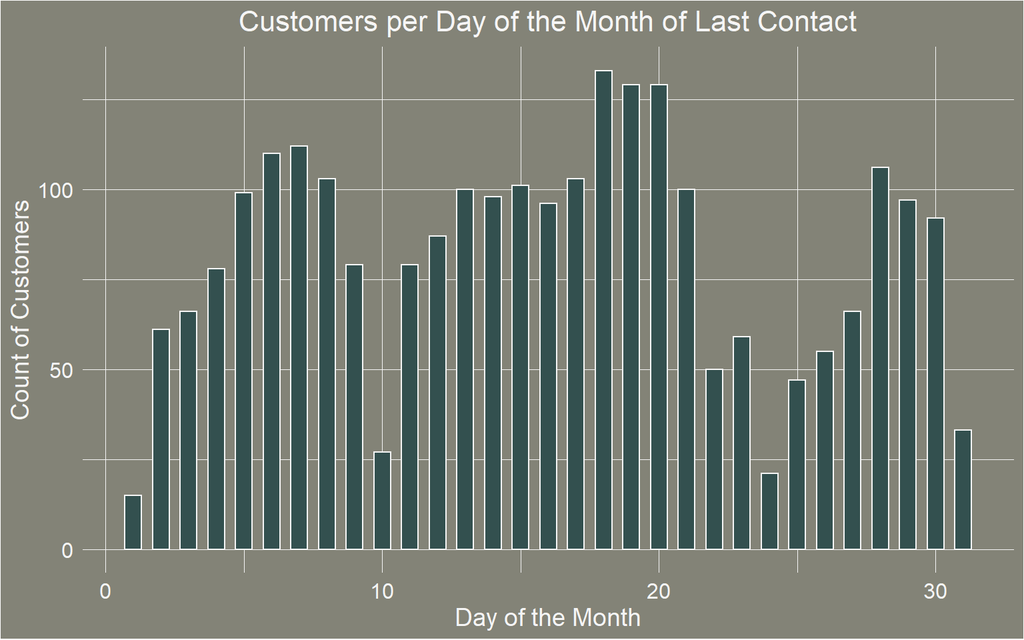

The number of customers per day of the month of the last contact is rather volatile. There are more contacts in the middle of months.

Let us have a look at the variations in subscription percentage between the days of the month.

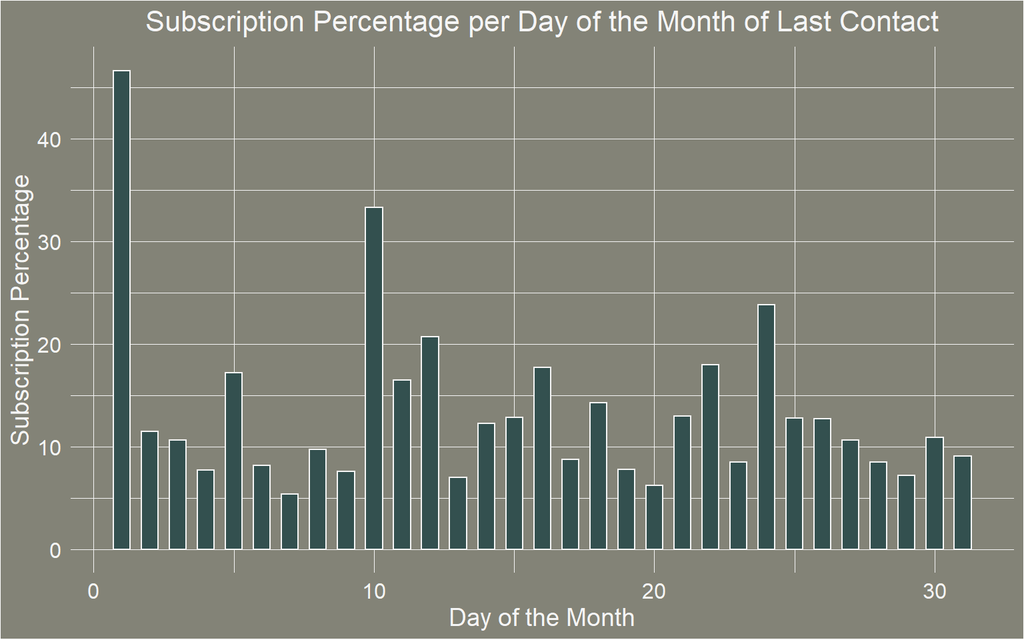

As previously noticed in the last but one graph above, the number of last contacts by day of the month is rather volatile. This holds also for the average subscription percentage by day of the month of the last contact with the customer in the reference marketing campaign.

Actually, comparing the evolution profiles in the last two graphs shows that they look partially counter-cyclical. For instance, the peaks pinpointed on the 1st, 10th, and 24th days in the average subscription percentage correspond to very low numbers of customers.

Will that predictor be influential?

### Month of Last Contact

The next predictor is also directly linked to the reference marketing campaign: it is the month of the last contact in the reference campaign. Is there a temporal pattern for the month of the last contact?

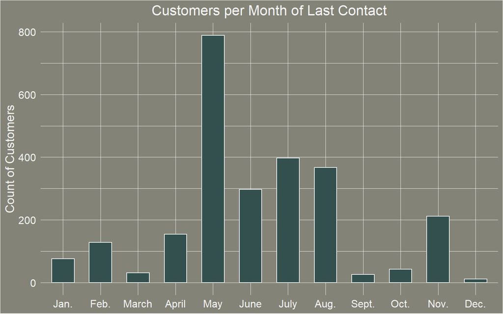

The last contact often took place from May to August. But how is this related to subscription percentages ?

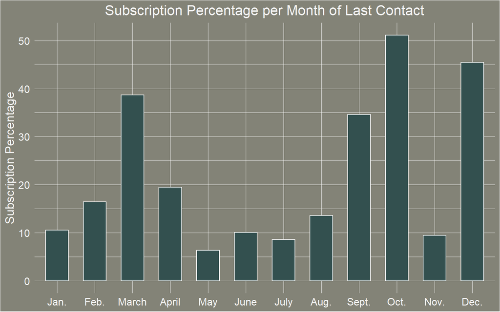

For instance, in the last but one graph above, we have noticed that for most customers the last contact in the reference marketing campaign takes place during the period May-August. But in the graph just above we can notice that the average percentages of subscription plummet in this period and culminate in October, December, March, and September.

Anyway, a counter-cyclical predictor can be influential as well.

### Duration of Last Contact

It is the duration of the contact whose results are to be predicted.

There is an important warning in the UCI Machine Learning Repository that contains the [Bank Marketing Data Set under review](https://archive.ics.uci.edu/ml/datasets/bank+marketing): “Important note: this attribute highly affects the output target (e.g., if duration=0 then y=‘no’). Yet, the duration is not known before a call is performed. Also, after the end of the call y is obviously known. Thus, this input should only be included for benchmark purposes and should be discarded if the intention is to have a realistic predictive model.”

So, there is a strong relationship between last contact duration and subscription probability. But using it here would be a bias in a predictive model. For that reason, and in complete agreement with the recommendations from the UCI Machine Learning Repository, this variable will not be taken into account. It will be discarded from the training, test, and validation sets.

### Number of Contacts

The number of contacts by customer can vary very much as shown in the table below. For most customers, the number of contacts in the reference marketing campaign is one, two or three. But the contacts by customer can attain the number of 50! The range is rather broad.

Is there an indication of subscription being linked to the number of contacts?

| Number of Contacts in Reference Campaign | Number of Customers | Average Subscription Percentage |
| --- | --- | --- |
| [1,2) | 965 | 15 |
| [2,3) | 711 | 10 |
| [3,5) | 494 | 13 |
| [5,10) | 267 | 7 |
| [10,51) | 94 | 2 |

In the table above, there are five subgroups of customers constituted on the basis of the number of contacts in the reference campaign. In the subgroup of customers with one contact, the subscription percentage is the highest, namely 15. The subscription decreases to 10 with two contacts, increases again to 13, and then falls stepwise to 2 in the subgroup with 10 contacts or more.

So, that table shows — measured at the level of these subgroups — a downward tendency between the number of contacts and the subscription percentage.

This might make sense, though! If there have already been let us say seven, eight, or nine contacts, I can imagine that there might be some hesitation from the customer!

### Last Contact Before Campaign

This is the first predictor related to previous marketing action — thus before the reference campaign whose data have been dealt with up to now.

| Days since Last Contact in Previous Campaign | Number of Customers | Average Subscription Percentage |
| --- | --- | --- |
| [-1,0) | 2083 | 9 |
| [0.1,50) | 8 | 25 |
| [50,100) | 65 | 51 |
| [100,250) | 188 | 23 |
| [250,500) | 182 | 12 |
| [500,1000) | 5 | 40 |

From the table above, it appears that the number of days since the last contact before the reference campaign is very often - 1! Actually, the value - 1 means that there was no contact before the reference campaign. It is so for the vast majority of customers, namely for 2,083 customers out of 2,531!

The average subscription percentage is pretty low in the large subgroup of customers who have not been contacted before the reference campaign. Is this so surprising? Selling on the phone to customers who have not been contacted by their bank in that way before can prove to be a tough challenge. Moreover, if they have not been contacted before, there might have been reasons…

In terms of average subscription percentage, there is a very marked contrast between the large subgroup without previous contact and most other subgroups. For instance, customers who, before the reference campaign, were last contacted between 50 and 100 days before, have an average subscription percentage of 51! This could turn out to be crucial information in a predictive model, even if the subgroup is rather small.

### Number of Contacts Before

This predictor will be partially redundant with respect to the previous one. Indeed, here, once again, we will find the scenario of customers not having been contacted before the campaign under review.

| Number of Previous Contacts | Number of Customers | Average Subscription Percentage |
| --- | --- | --- |
| [0,1) | 2083 | 9 |
| [1,5) | 371 | 22 |
| [5,10) | 61 | 23 |
| [10,26) | 16 | 25 |

In the table above, we can find back the 2,083 customers who had not been contacted before the campaign under analysis.

Zero previous contact is associated with a rather low average subscription rate of 9%. The average subscription percentage is significantly higher in the subgroups with previous contact(s): it is pretty uniform, in a range of 22%–25%.

The dichotomy between the subgroup without previous contact and the subgroups with previous contact(s) looks potentially useful in a predictive model.

### Previous Campaign Outcome

This is the last predictor. Of course, we will find — once again — the exact same piece of information about the 2,083 customers who had not been contacted before the marketing campaign under analysis. But maybe there is some additional information.

| Outcome from Previous Campaign | Number of Customers | Average Subscription Percentage |
| --- | --- | --- |
| failure | 275 | 12 |
| other | 107 | 19 |
| success | 66 | 71 |
| unknown | 2083 | 9 |

There is, indeed, some very interesting new information. Apart from the 2,083-customer subgroup, the subgroup of customers who were previously contacted and who previously opted for term deposits shows an extraordinary average subscription rate of 71%. That looks like a piece of information with a very significant potential predictive power, at least for this rather small subgroup.

## Insights from EDA

Let us summarize the pieces of information gleaned during the Exploratory Data Analysis.

### Prevalence & Performance Metrics

The positive class represents only 11.5% of all bank customers while the negative class represents 88.5%. Applying a base model — predicting no term deposit for everyone — would already give, on the training set, an accuracy of 88.5%. Indeed, accuracy equals the addition of the proportion of true negatives — that would be 88.5% in the base model — and the proportion of true positives — that would be 0% in the base model.

But sensitivity would be zero since sensitivity is the number of true positives — which would be zero in the base model — divided by the number of all actual positives! Consequently, other performance metrics had to be picked up.

So, the objective has been formulated as the maximization of sensitivity under a double constraint:

- on the one hand, the total of predicted positives — in other words the customers targeted — should not exceed 50%;
- on the other hand, sensitivity should be at least 75%.

Maximization under constraint applies to training, test, and validation sets.

### Insights about Predictors

Each predictor provides a segmentation of customers into subgroups, each subgroup having its average subscription percentage. In the Exploratory Data Analysis, some remarkable subgroups have been noted from the point of view of subscription percentages:

- customers older than 60 have an average subscription percentage higher than the other age categories; that also holds, in a more limited way, for customers younger than 25;
- as far as professional status is concerned, higher average subscription rates are observed for students, retired people, and customers with “unknown” professional status while, on the contrary, the subgroups of entrepreneurs and unemployed customers have the lowest subscription percentage;
- the subgroup of married people has a lower subscription percentage than single and divorced people — widows and widowers being included in the subgroup of divorced people in the taxonomy of the dataset under review;
- customers with tertiary education form a subgroup with the highest subscription percentage with respect to other education levels;
- it is the same for customers with an account balance between 1,000 and 10,000;
- the subgroups of customers with home loans or personal loans have lower subscription percentages;
- the same holds for customers for whom the medium of communication is unknown;
- we can see higher subscription percentages than average when the last contact in this campaign is in October, December, March, or September and lower from May until August;
- the subgroup of customers who have been contacted just once in the campaign under review has a higher average subscription percentage;
- segmentation on the basis of previous marketing action indicates the following: customers who favorably responded in a previous marketing campaign have an exceptionally high average subscription rate; the same holds, but to a lesser extent, for customers for whom the last contact in a previous campaign is between 50 and 100 days; but customers who had not been contacted in previous marketing action, which is a vast majority, have a much lower subscription percentage on average than the other subgroups.

Last contact duration has been discarded to prevent bias in a predictive model, on the recommendation of the UCI Machine Learning Repository.

Let us express a caveat about some subgroups and their subscription percentages: some subgroups are rather small and this might affect the predictive power of the associated subscription percentages.

We are now ready to turn to modeling on the training set.

## Data Analytics with ML

Let us use the training set to try several machine learning algorithms available in the caret package. They will be tested later on the test set before a final model is chosen and then validated just once on the validation set.

### ML Models on Training Set

Twenty-one Machine Learning algorithms have been tried, such as qda, knn, kknn, svmLinear, svmRadial, svmRadialCost, svmRadialSigma, rpart, rf, ranger, wsrf, Rborist, monmlp, etc. After many trials on the training set and on the test set, four algorithms have been selected: * glm or Generalized Linear Model, * lda or Linear Discriminant Analysis, * xgbTree or eXtreme Gradient Boosting, * and gbm or Stochastic Gradient Boosting.

The four selected algorithms will be run with the train() function from the caret package.

For each model, two measures will be computed:

- the percentage of interested customers reached, that is to say sensitivity — or recall — multiplied by 100;
- the targeting reduction, that is to say the percentage of customers for whom the model prediction is “no_deposit”.

These are the two criteria to use to evaluate model performance.

The objective is maximizing sensitivity under the double constraint that targeting reduction and sensitivity are at least respectively 50% and 75%.

Asking for targeting reduction being at least 50% or asking for the predicted positives representing no more than 50% of all customers — as expressed here — is mathematically equivalent but targeting reduction has seemed visually preferable when visualizing performance in graphs.

The programming language is R, which, like Python, is best suited for this kind of work.

| Predictive Model | Interested Customers Reached (sensitivity) | Targeting Reduction |
| --- | --- | --- |
| xgbTree | 17 % | 97 % |
| gbm | 17 % | 97 % |
| glm | 19 % | 97 % |
| lda | 24 % | 95 % |

Let us scrutinize the first predictive results generated on the training set by the four Machine Learning models and recorded in the table above.

### Challenges in ML

The table above shows that no model respects the constraint of a minimum sensitivity level — the percentage of interested customers reached — of 75%. All results are below 25%!

In contrast, the constraint of a minimum targeting reduction of 50% is more than satisfied with percentages above 90%!

The challenge will be to rebalance the results between the two criteria.

It can also be noted that the four models are very close to each other in performance metric results. xgbTree and gbm even have the exact same results after rounding.

Let us situate erroneous predictions — that is to say, false positives and false negatives — among all results from the confusion matrices.

| Predictive Model | True Positives | False Positives | False Negatives | True Negatives |
| --- | --- | --- | --- | --- |
| glm | 54 | 26 | 237 | 2214 |
| lda | 70 | 46 | 221 | 2194 |
| xgbTree | 49 | 17 | 242 | 2223 |
| gbm | 49 | 21 | 242 | 2219 |

The table above calls for various observations, among others the following ones.

First, the number of positive predictions — correct or not — is far below the number of customers opting for term deposits. For instance, for the glm model, the number of positive predictions is 80 — true positives plus false positives —, contrasting with the much higher number of 291 customers actually interested in term deposits. This number of 291 actually interested customers — equal to true positives and false negatives together — is a fixed statistic of the training dataset regardless of the chosen model.

Therefore, for the glm model, even if all 80 positive predictions were correct, sensitivity would only be 27% and would still be far from the required minimum sensitivity of 75%.

The next graph situates the performance level of each model with respect to the target area — that is to say the locus of all combinations of performance metric results that satisfy the constraints of a minimum sensitivity of 75% and of a minimum targeting reduction of 50%.

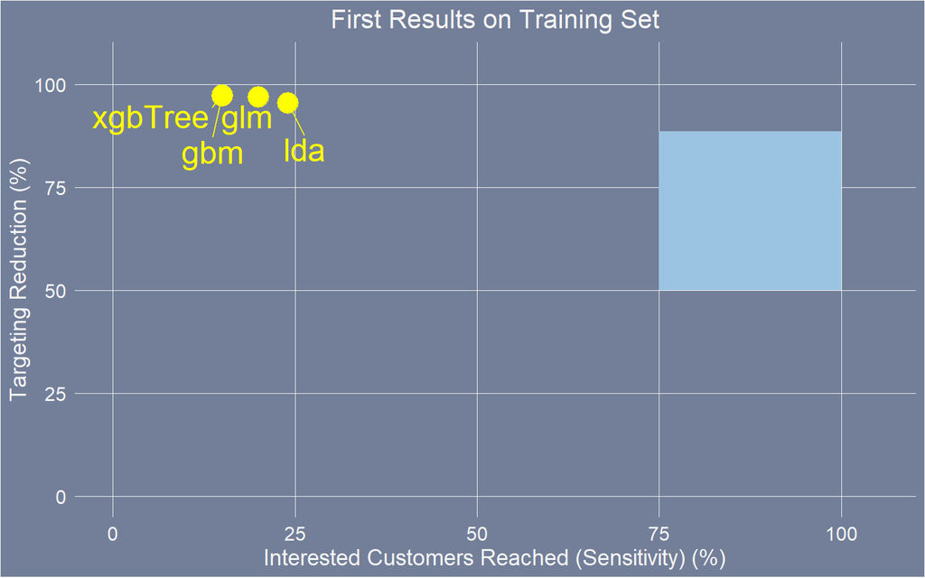

The target area is represented by the soft blue rectangle in the upper right corner. The target area is the locus of all combinations of sensitivity — percentage of interested customers reached — and of targeting reduction percentage that satisfy our two constraints: minimum sensitivity of 75% and minimum targeting reduction of 50%.

Each model is represented by a point with its label. The coordinates of the points are calculated with the default probability threshold 0.5 to decide whether the fitted value for a customer should be “deposit” or “no_deposit”. Should we lower the probability threshold to predict more customers interested in term deposits and drastically reduce the number of false negatives?

Let us retrieve probabilities for each model and analyze for instance the probabilities from the lda model.

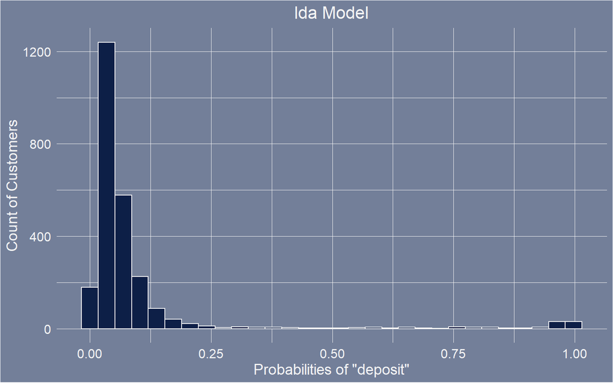

The graph above indicates very few customers with a subscription probability higher than 0.50.

This constitutes a decisive insight: with such a histogram, applying a probability threshold of 0.50 when predicting subscription is incompatible with predicting subscription for 11.5% or more of the customers.

By drilling down a little into data, we can see that * the number of customers with a subscription probability equal to or higher to 0.50 is 116 * and that the number of actually interested customers is 291.

Consequently, when applying a 0.50 threshold, even if prediction precision were 100% — that is to say even if there were no false positives — the lda model could not identify all interested customers and far from it. It is a mathematical impossibility.

To select more customers, we can create more leeway by lowering the probability threshold.

### Challenge Met with Thresholding

Thresholding below 0.5 will be performed for all models.

Performance metric results are recorded in the next table for a few probability thresholds.

| Thresh | glm_s | glm_r | lda_s | lda_r | xgb_s | xgb_r | gbm_s | gbm_r |
| --- | --- | --- | --- | --- | --- | --- | --- | --- |
| 0.03 | 98 | 13 | 92 | 27 | 99 | 3 | 100 | 0 |
| 0.035 | 96 | 18 | 90 | 34 | 99 | 5 | 100 | 0 |
| 0.04 | 95 | 22 | 87 | 41 | 99 | 7 | 100 | 0 |
| 0.045 | 93 | 26 | 81 | 49 | 98 | 12 | 100 | 0 |
| 0.05 | 91 | 29 | 77 | 54 | 98 | 16 | 100 | 0 |
| 0.055 | 91 | 32 | 74 | 59 | 97 | 21 | 100 | 3 |
| 0.06 | 90 | 36 | 69 | 63 | 95 | 25 | 98 | 11 |
| 0.065 | 88 | 40 | 66 | 67 | 94 | 28 | 97 | 18 |
| 0.07 | 85 | 43 | 64 | 70 | 91 | 33 | 95 | 22 |
| 0.075 | 82 | 47 | 59 | 74 | 89 | 36 | 93 | 25 |
| 0.08 | 79 | 50 | 56 | 76 | 87 | 40 | 91 | 30 |
| 0.085 | 77 | 54 | 52 | 78 | 85 | 44 | 89 | 34 |
| 0.09 | 75 | 57 | 51 | 80 | 83 | 49 | 84 | 45 |
| 0.095 | 72 | 60 | 48 | 82 | 82 | 54 | 81 | 52 |
| 0.1 | 70 | 62 | 47 | 83 | 79 | 56 | 73 | 61 |

In the table above, “Thresh” obviously refers to probability thresholds.

“glm_s” heads the column of percentages of interested customers reached (“s” standing of course for “sensitivity”) for the glm model. The equivalents hold of course for the lda model, etc.

“glm_r” heads the column of targeting reductions (“r” standing of course for “reduction”) for the glm model. The equivalents hold of course for the lda model, etc.

The very concepts of percentage of interested customers reached and of targeting reduction have been explained here.

Thresholding allows all four models — glm, lda, xgbTree, and gbm — to satisfy both constraints of the optimization objective. For instance, as shown in the table above, for the glm model a probability threshold of 0.08 induces a targeting reduction of 50% — which is the minimum required — and a sensitivity of 79% — while the minimum requested is 75%.

Let us visualize the performance metric results from the four predictive models in the next graph.

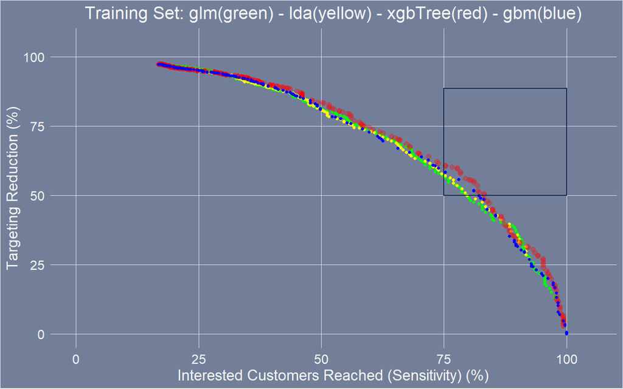

This graph provides an overview of the performance of the four models, with negative aspects but also positive aspects. These aspects deserve a thorough analysis, which is the subject of the next section.

### Thresholding Impact

As clearly shown in the graph above, the result lines of the four predictive models intersect with the target rectangle — which is surrounded by a deep blue perimeter.

In the graph above, the xgbTree model is represented in red. The series of points descends to the right in a curved profile as the probability decreases. The xgbTree model is the most performing one. It has the most advanced position in the target rectangle in terms of sensitivity — percentage of interested customers reached — or in terms of targeting reduction. It is present in the target rectangle in a fairly dense way.

The gbm model, in blue, comes next, with a few points. For gbm, points are rather close to each other at the top of the curve — where the probability threshold is close to 0.5 — and at the bottom of the curve — where the probability threshold is close to zero. Points are more distant from each other in between.

The glm model, represented in green, also passes through the target area, a little bit left of the gbm model.

The lda model is represented in yellow. It slightly touches the target area. It also has the shortest range in terms of sensitivity — percentage of interested customers reached — and in terms of targeting reduction.

## Testing Predictive Models

All four models will run on the test set; insights are expected to define an effective way forward.

### ML Challenge on Test Set

On the test set, let us use the predict() function from the caret package to retrieve the probabilities of “deposit”.

Let us then select a sequence of probability thresholds, compute sensitivity and targeting reduction for each threshold and for each model, analyze results, and possibly move forward.

Here is a table with a few probability thresholds and corresponding sensitivity and targeting reduction for the four predictive models. Probability thresholds have been selected to show the best performance metric results for each model.

| Thresh | glm_s | glm_r | lda_s | lda_r | xgbTree_s | xgbTree_r | gbm_s | gbm_r |
| --- | --- | --- | --- | --- | --- | --- | --- | --- |
| 0.049 | 89 | 26 | 73 | 49 | 95 | 12 | 100 | 0 |
| 0.05 | 88 | 27 | 71 | 50 | 95 | 12 | 100 | 0 |
| 0.051 | 88 | 27 | 71 | 51 | 95 | 13 | 100 | 0 |
| 0.052 | 88 | 27 | 71 | 52 | 95 | 13 | 100 | 0 |
| 0.086 | 74 | 49 | 52 | 78 | 81 | 41 | 85 | 31 |
| 0.087 | 74 | 50 | 52 | 78 | 81 | 42 | 82 | 37 |
| 0.088 | 73 | 51 | 52 | 79 | 79 | 43 | 82 | 37 |
| 0.089 | 73 | 52 | 52 | 79 | 78 | 44 | 82 | 37 |
| 0.093 | 71 | 54 | 51 | 81 | 71 | 48 | 74 | 45 |
| 0.094 | 70 | 54 | 49 | 81 | 71 | 48 | 71 | 48 |
| 0.095 | 70 | 55 | 49 | 82 | 71 | 50 | 71 | 48 |
| 0.096 | 68 | 55 | 49 | 82 | 71 | 51 | 67 | 54 |

Some practical explanations of a similar table are available here.

In the table just above, no model satisfies the two maximization constraints for one threshold. These constraints are: * sensitivity equal to or higher than 75% * and, at the same time, targeting reduction equal to or higher than 50%.

Let us graphically visualize the performance metric results from the four models for numerous thresholds.

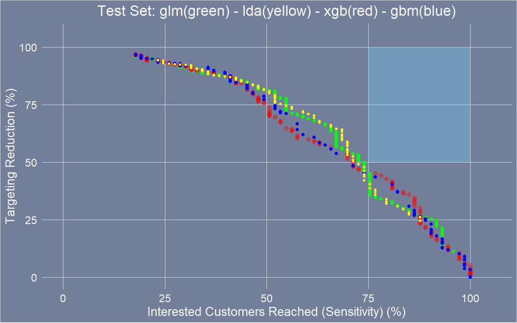

No model meets the target. Performance decrease is more marked for the xgbTree and gbm models with respect to the performance results on the training set.

Let us build an ensemble model to possibly improve performance and/or prediction stability.

### Tentative Solution: Ensembling

Out of the four algorithms applied to the training set, ensembling has been tried on the test set with various combinations. Finally, a combination of glm, xgbTree, and gbm has been chosen.

For the ensemble model — just as this has been done for the four individual models — two performance metrics will be computed: the percentage of interested customers reached — that is to say sensitivity — and the targeting reduction.

Another structure had also been tried for the ensemble model. A majority vote had been organized among three individual series of predictions already individually optimized with three different thresholds, one series for glm, one for xgbTree, and one for gbm. This alternative ensemble model underperformed on the test set with respect to the chosen ensemble model and has consequently been dropped.

Here is a table of results comparing performance from glm, xgbTree, gbm, and the ensemble model.

| Thresh | glm_s | glm_r | xgbTree_s | xgbTree_r | gbm_s | gbm_r | ens_s | ens_r |
| --- | --- | --- | --- | --- | --- | --- | --- | --- |
| 0.086 | 74 | 49 | 81 | 41 | 85 | 31 | 81 | 39 |
| 0.087 | 74 | 50 | 81 | 42 | 82 | 37 | 81 | 42 |
| 0.088 | 73 | 51 | 79 | 43 | 82 | 37 | 79 | 43 |
| 0.089 | 73 | 52 | 78 | 44 | 82 | 37 | 79 | 44 |
| 0.09 | 73 | 53 | 77 | 45 | 81 | 40 | 79 | 46 |
| 0.091 | 73 | 53 | 73 | 47 | 77 | 43 | 75 | 48 |
| 0.092 | 73 | 53 | 73 | 47 | 77 | 43 | 75 | 48 |
| 0.093 | 71 | 54 | 71 | 48 | 74 | 45 | 73 | 50 |
| 0.094 | 70 | 54 | 71 | 48 | 71 | 48 | 73 | 50 |
| 0.095 | 70 | 55 | 71 | 50 | 71 | 48 | 73 | 51 |
| 0.096 | 68 | 55 | 71 | 51 | 67 | 54 | 70 | 54 |

The table above is not comprised of any performance metric results satisfying both constraints — that is to say a minimum sensitivity of 75% and a minimum targeting reduction of 50%. The series of two predictive models do not pass far from the target rectangle: a combination of 74% sensitivity and 50% targeting reduction is recorded for the glm model and associations like 75%-48% or 73%-50% are registered for the ensemble model.

Let us graphically visualize results from the four predictive models.

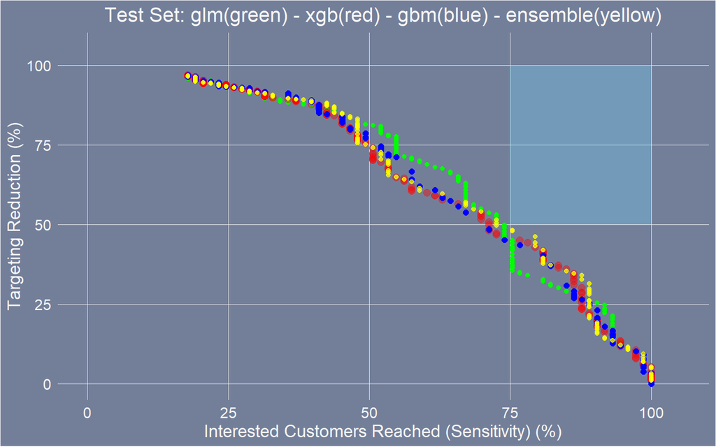

The point series zigzag along the lower left corner of the target rectangle without brushing against it.

As already seen in the last table above, the glm model — in green — and the ensemble model — in yellow — pass not far from the lower left corner of the target rectangle.

Just above 50% sensitivity, the glm model — in green — outperforms the other ones in that for the same targeting reduction level it has a higher sensitivity — that is to say a higher percentage of interested customers reached. Just above 75% sensitivity, the glm underperforms.

The ensemble model is chosen as final model for the following reasons: * more stability is expected from the overall model due to its composite structure; * it comes close to the target rectangle on the test set; * just above 75% sensitivity, it performs several times slightly better than the other models with higher sensitivity for the same targeting reduction levels.

Vis-à-vis the performance levels reached by the ensemble model on the test set, an improvement is expected on the validation set because the very small size of the test set might have impeded performance.

## Predicting on Validation Set

Three predictive models compose the ensemble model as explained here. The three components will first be run on the validation set, then the ensemble model will be constructed on top of them.

Thresholding on the test set has provided useful insight about the threshold: a threshold value of 0.094 — as shown here — has maximized sensitivity for the ensemble model on the test set while satisfying the constraint of a minimum of 50% for targeting reduction. The exact same threshold value will be applied to build up the ensemble model on the validation set.

| Predictive Model | Prospects Targeted | Interested Customers Reached (Sensitivity) |
| --- | --- | --- |
| Ensemble xgbTree-glm-gbm | 49 % | 80 % |

The objective in this project was clear: maximizing the percentage of interested customers reached — sensitivity — with a minimum sensitivity of 75% and while predicting as positives no more than 50% of all customers.

This objective has been more than achieved: the percentage of interested customers reached — sensitivity — is 80 and the percentage of customers targeted is 49%.

## Some Takeaways

Besides the final results, this project has shown the possible impact of Machine Learning, in this case with classifications algorithms, probability thresholding, and ensembling.

Probability thresholding has proved decisive on the training, test, and validation sets.

The test set has shown the fragility of results obtained on a training set: performance dropped on the test set and the ranking of models was altered. Ensembling combined with probability thresholding has been tried on the test set and applied to the validation set, where it has met the objective: 80% of interested customers reached while limiting the customers targeted to 49%.

Here is [my GitHub account](https://github.com/Dev-P-L), with contact information. You are welcome to get in touch.